# Medidas

ProbEst

fnaufel

17/09/2021

# 1 Medidas de centralidade

## 1.1 Média

### 1.1.1 De uma população

- Média de uma população:
  $$\mu = \frac{\sum x}{N}$$
- $\sum x$ é a soma de todos os dados $x$.
- $N$ é a quantidade de elementos na população.

### 1.1.2 De uma amostra

- Média de uma amostra:
  $$\bar x = \frac{\sum x}{n}$$
- $\sum x$ é a soma de todos os dados $x$.
- $n$ é a quantidade de elementos na amostra.

### 1.1.3 Exemplo

Idades dos alunos de uma turma:

```r
idades <- c(
  20, 20, 20, 20, 20, 20, 21, 21, 21, 21, 22, 22, 22, 23, 23, 23, 23, 24, 24, 65
)
```

Média com o velhinho:

```r
mean(idades)
```

```
## [1] 23,75
```

Média sem o velhinho:

```r
mean(idades[-length(idades)])
```

```
## [1] 21,57895
```

## 1.2 Mediana

- Já vimos no vídeo sobre *boxplots*.
- 50% dos dados à esquerda, 50% à direita.
- Não é tão sensível a *outliers*.

### 1.2.1 Exemplo

Mediana com o velhinho:

```r
median(idades)
```

```
## [1] 21,5
```

Mediana sem o velhinho:

```r
median(idades[-length(idades)])
```

```
## [1] 21
```

# 2 Formas de uma distribuição

- O histograma mostra aspectos importantes de uma distribuição.
- A *moda* é o valor mais comum. Pode haver mais de uma moda.
- Uma função para retornar um histograma:

```r
histograma <- function(
  dados,
  divisoes = floor(min(dados)):ceiling(max(dados))
) {

  dados %>%
    as_tibble() %>%
    ggplot(aes(x = value)) +
      geom_histogram(breaks = divisoes, color = 'black', fill = '#00000000') +
      scale_x_continuous(breaks = divisoes)

}
```

- Histograma das idades da turma:

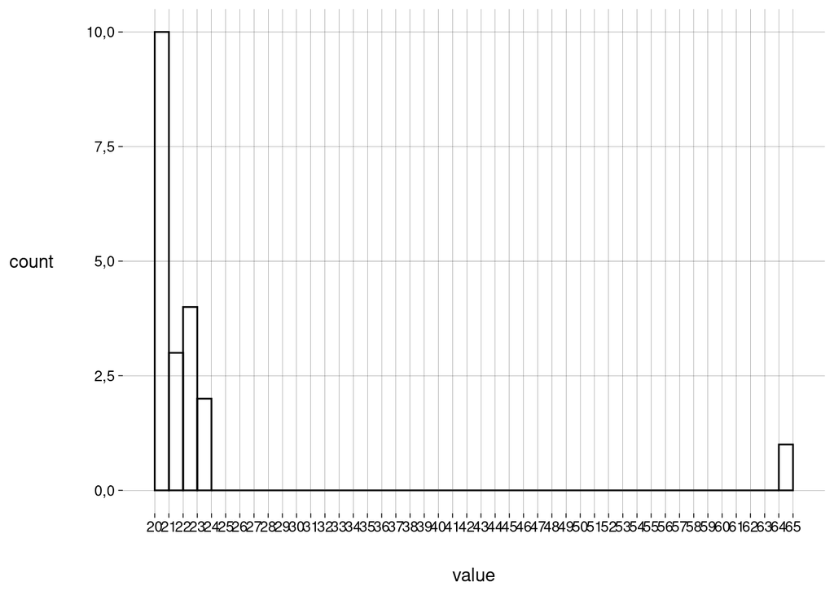

```r
histograma(idades)
```

## 2.1 Distribuição Uniforme

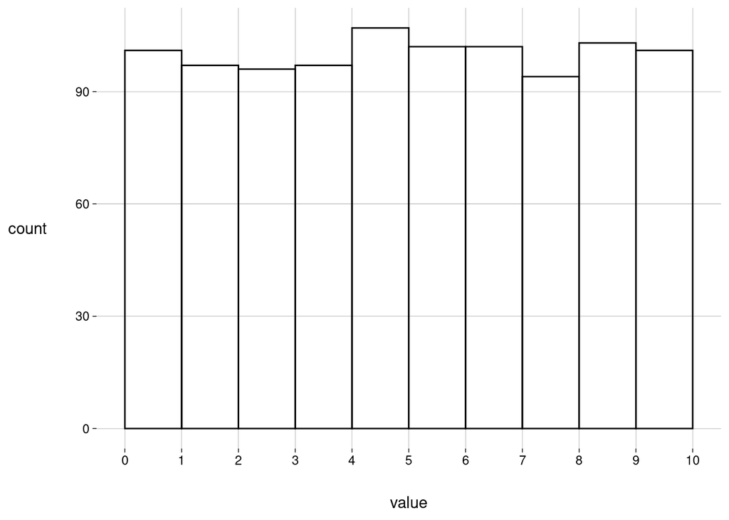

```r
uniforme <- runif(1000, min = 0, max = 10)

histograma(uniforme)
```

- A distribuição uniforme não tem moda.

## 2.2 Simétrica

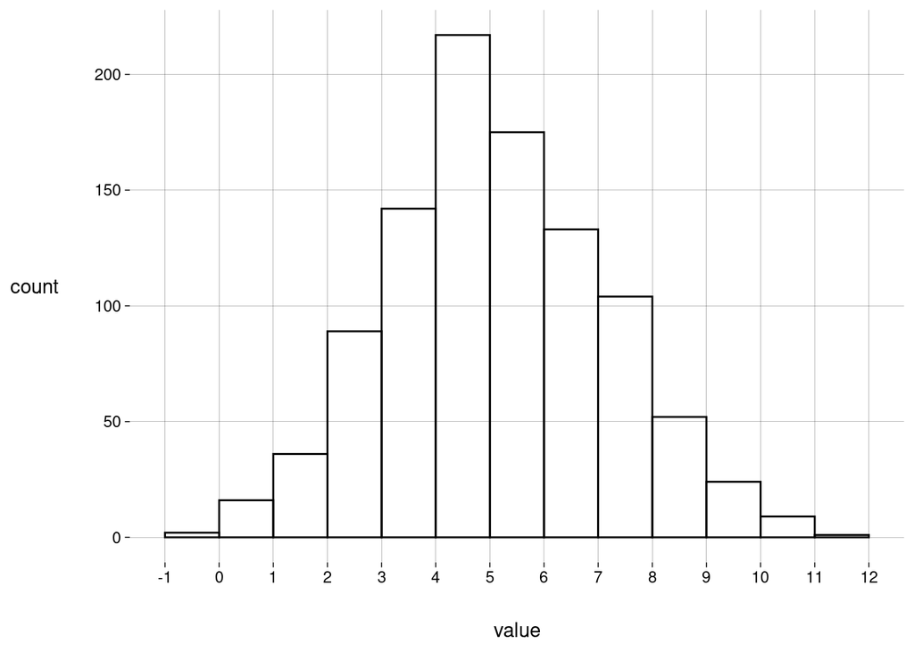

```r
sim <- rnorm(1000, mean = 5, sd = 2)
histograma(sim)
```

- A distribuição uniforme também é simétrica.
- Esta distribuição é unimodal.
- A média, a mediana e a moda coincidem:

```r
mean(sim)
```

```
## [1] 5,140687
```

```r
median(sim)
```

```
## [1] 4,991479
```

- Por que não existe uma função para a moda em R? Porque, por incrível que pareça, é complicado calcular a moda para dar resultados interessantes.

```r
# Por causa de um bug na função mfv,
# precisamos de números com ponto decimal
# (em vez de vírgula)
options(OutDec = '.')
mfv(sim)
```

[output not shown]

[output cut: 152 more lines]

```r
options(OutDec = ',')
```

- Um método possível: centro do intervalo mais curto que contém metade das observações:

```r
mlv(sim, method = 'venter')
```

```
## [1] 4,871706
```

- **Exercício**: arrendondar os valores no vetor `sim` para 3 casas decimais e usar `mfv` para descobrir a(s) moda(s).
- Uma distribuição bimodal:

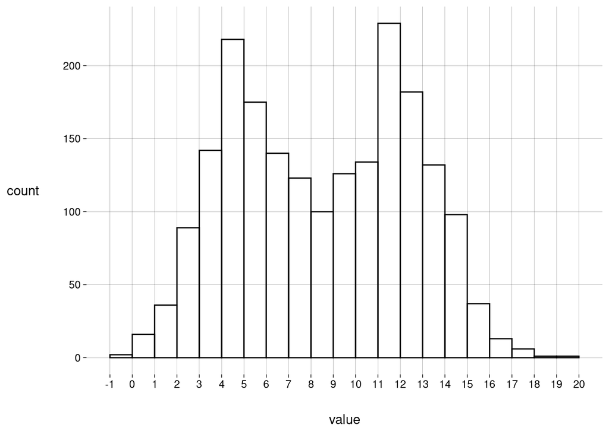

```r
sim2 <-  rnorm(1000, mean = 12, sd = 2)
bimodal <- c(sim, sim2)

histograma(bimodal)
```

## 2.3 Assimétrica

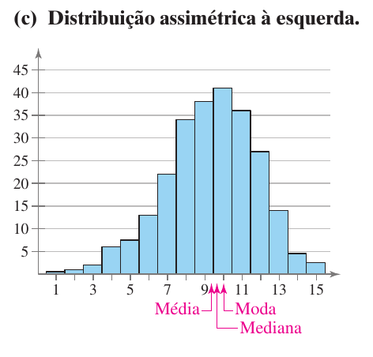

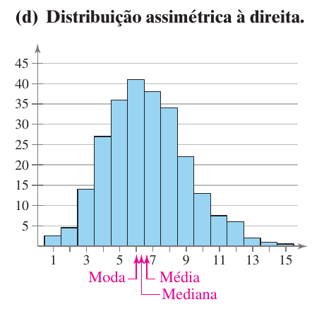

- Um exemplo: salários de CEOs

```r
df <- read_csv('./CEO_Salary_2012.csv')
glimpse(df)
```

```
## Rows: 500
## Columns: 9
## $ Rank                  <dbl> 1, 2, 3, 4, 5, 6, 7, 8, 9, 10, 11, 12, 13, 14, 1…
## $ Name                  <chr> "John H Hammergren", "Ralph Lauren", "Michael D …
## $ Company               <chr> "McKesson", "Ralph Lauren", "Vornado Realty", "K…
## $ `1-Year Pay ($mil)`   <dbl> 131,190, 66,650, 64,405, 60,940, 55,790, 51,525,…
## $ `5 Year Pay ($mil)`   <dbl> 285,020, 204,060, NA, 60,940, 96,110, 100,210, 9…
## $ `Shares Owned ($mil)` <dbl> 51,9, 5010,4, 171,7, 8582,3, 21,5, 47,3, 128,2, …
## $ Age                   <dbl> 53, 72, 55, 67, 59, 57, 55, 59, 61, 60, 59, 56, …
## $ Efficiency            <dbl> 121, 84, NA, NA, 138, 36, 12, NA, 91, 131, 150, …
## $ `Log Pay`             <dbl> 8,117901, 7,823800, 7,808920, 7,784902, 7,746556…
```

```r
salarios <- df %>%
  select(Name, valor = `1-Year Pay ($mil)`)
```

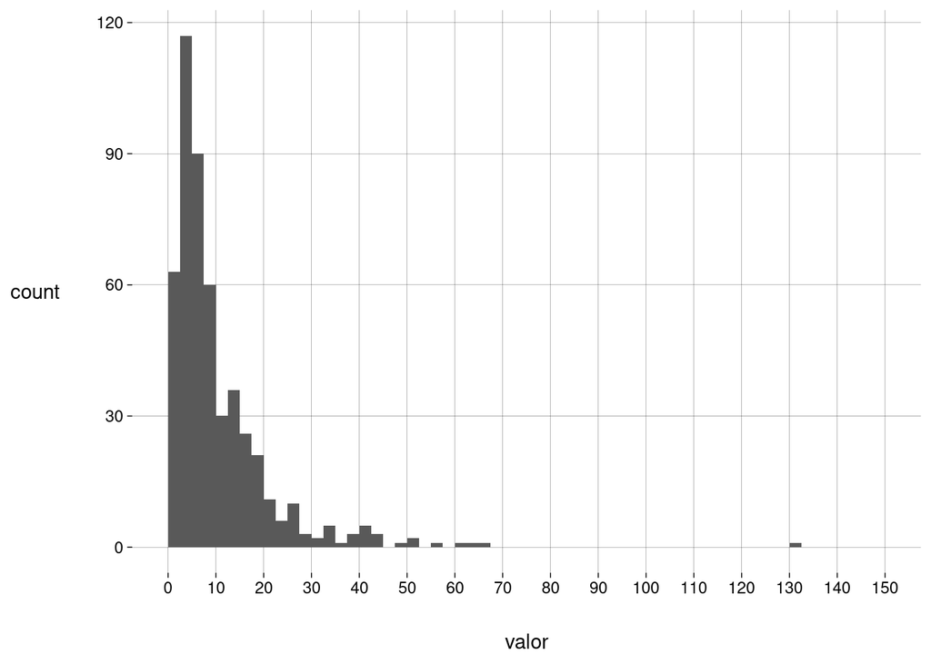

```r
salarios %>%
  ggplot(aes(x = valor)) +
    geom_histogram(breaks = seq(0, 150, 2.5)) +
    scale_x_continuous(breaks = seq(0, 150, 10))
```

```r
# Por causa de um bug na função mfv,
# precisamos de números com ponto decimal
# (em vez de vírgula)
options(OutDec = '.')
sumario <- salarios %>%
  summarise(
    media = mean(valor),
    mediana = median(valor),
    moda = list(mfv(valor))
  )
options(OutDec = ',')

sumario
```

| media | mediana | moda |
| --- | --- | --- |
| 10,47583 | 6,9675 |  |

```r
sumario$moda
```

```
## [[1]]
## [1]  0,00  2,00 10,45
```

```r
salarios %>%
  filter(valor %in% sumario$moda[[1]])
```

| Name | valor |
| --- | --- |
| Glenn M Renwick | 10,45 |
| Jeffrey A Joerres | 10,45 |
| Ronald L Havner Jr | 10,45 |
| Louis J D'Ambrosio | 2,00 |
| Thomas M Rutledge | 2,00 |
| Scott Thompson | 2,00 |
| Malon Wilkus | 0,00 |
| Matthew J Lambiase | 0,00 |
| Larry Page | 0,00 |

```r
salarios %>%
  filter(valor == max(valor))
```

| Name | valor |
| --- | --- |
| John H Hammergren | 131,19 |

# 3 Re-expressão

```r
salarios_log <- salarios %>%
  mutate(log_valor = log10(valor))
```

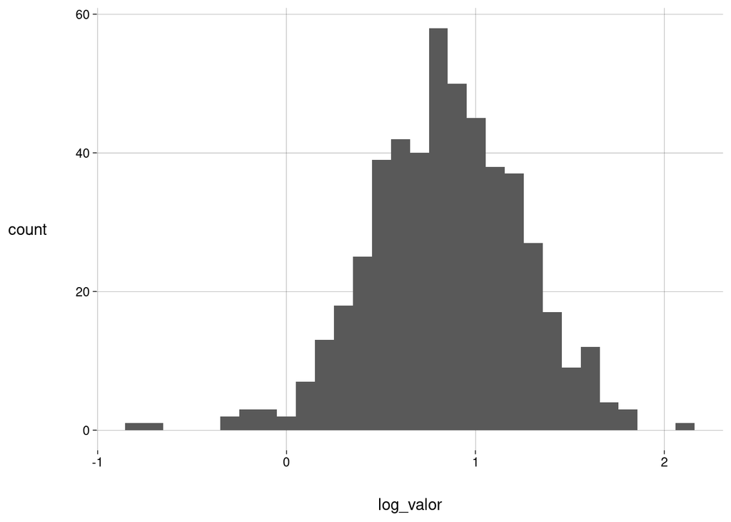

```r
salarios_log %>%
  ggplot(aes(x = log_valor)) +
    geom_histogram()
```

# 4 Medidas de posição

## 4.1 Quantis

```r
salarios %>%
  pull(valor) %>%
  quantile()
```

```
##        0%       25%       50%       75%      100%
##   0,00000   3,88500   6,96750  13,36125 131,19000
```

```r
salarios %>%
  pull(valor) %>%
  quantile(c(.01, .05, .1))
```

```
##      1%      5%     10%
## 0,48695 1,48405 2,19400
```

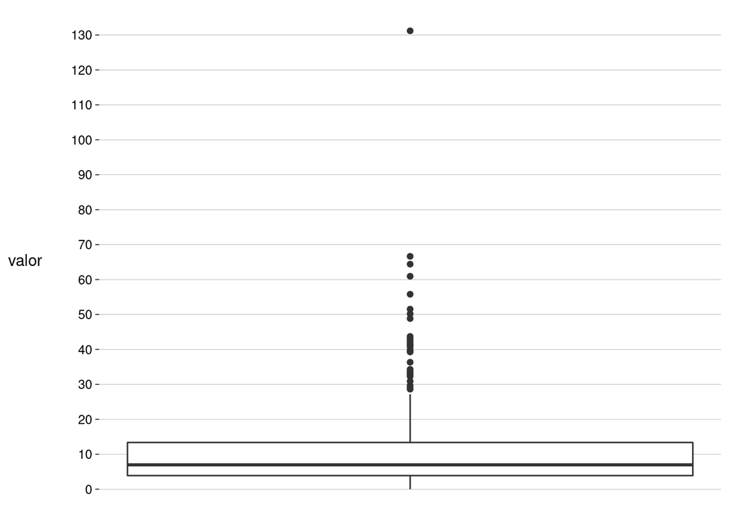

```r
salarios %>%
  ggplot(aes(y = valor)) +
    geom_boxplot() +
    scale_x_continuous(breaks = NULL) +
    scale_y_continuous(breaks = seq(0, 150, 10))
```

# 5 Medidas de dispersão

## 5.1 Amplitude

```r
idades
```

```
##  [1] 20 20 20 20 20 20 21 21 21 21 22 22 22 23 23 23 23 24 24 65
```

```r
range(idades)
```

```
## [1] 20 65
```

```r
range(idades)[2] - range(idades)[1]
```

```
## [1] 45
```

## 5.2 IQR

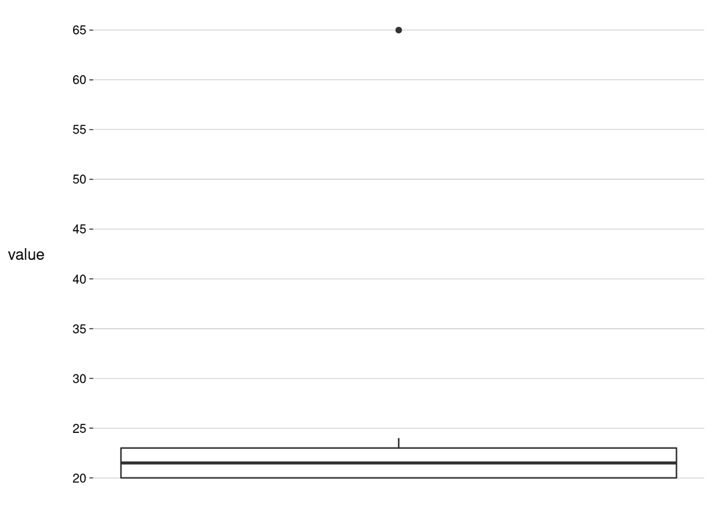

```r
idades %>%
  as_tibble() %>%
  ggplot(aes(y = value)) +
    geom_boxplot() +
    scale_x_continuous(breaks = NULL) +
    scale_y_continuous(breaks = seq(20, 70, 5))
```

```r
summary(idades)
```

```
##    Min. 1st Qu.  Median    Mean 3rd Qu.    Max.
##   20,00   20,00   21,50   23,75   23,00   65,00
```

```r
IQR(idades)
```

```
## [1] 3
```

```r
IQR(salarios$valor)
```

```
## [1] 9,47625
```

## 5.3 Variância

- Pesos e alturas de um time de basquete:

```r
medidas <- tibble(
  altura = .025 * c(72, 74, 68, 76, 74, 69, 72, 79, 70, 69, 77, 73),
  peso = 0.45 * c(180, 168, 225, 201, 189, 192, 197, 162, 174, 171, 185, 210)
)

medidas
```

| altura | peso |
| --- | --- |
| 1,800 | 81,00 |
| 1,850 | 75,60 |
| 1,700 | 101,25 |
| 1,900 | 90,45 |
| 1,850 | 85,05 |
| 1,725 | 86,40 |
| 1,800 | 88,65 |
| 1,975 | 72,90 |
| 1,750 | 78,30 |
| 1,725 | 76,95 |

[output cut: 2 more lines]

```r
summary(medidas$altura)
```

```
##    Min. 1st Qu.  Median    Mean 3rd Qu.    Max.
##   1,700   1,744   1,812   1,819   1,863   1,975
```

```r
summary(medidas$peso)
```

```
##    Min. 1st Qu.  Median    Mean 3rd Qu.    Max.
##   72,90   77,96   84,15   84,53   89,10  101,25
```

### 5.3.1 Desvios

- Diferenças entre cada valor e a média:

```r
d_medidas <- medidas %>%
  mutate(
    d_altura = altura - mean(altura),
    d_peso = peso - mean(peso)
  )

d_medidas
```

| altura | peso | d_altura | d_peso |
| --- | --- | --- | --- |
| 1,800 | 81,00 | -0,01875 | -3,525 |
| 1,850 | 75,60 | 0,03125 | -8,925 |
| 1,700 | 101,25 | -0,11875 | 16,725 |
| 1,900 | 90,45 | 0,08125 | 5,925 |
| 1,850 | 85,05 | 0,03125 | 0,525 |
| 1,725 | 86,40 | -0,09375 | 1,875 |
| 1,800 | 88,65 | -0,01875 | 4,125 |
| 1,975 | 72,90 | 0,15625 | -11,625 |
| 1,750 | 78,30 | -0,06875 | -6,225 |
| 1,725 | 76,95 | -0,09375 | -7,575 |

[output cut: 2 more lines]

- Vamos calcular os desvios médios!

```r
d_medidas %>%
  summarize(
    d_medio_altura = mean(d_altura),
    d_medio_peso = mean(d_peso)
  )
```

| d_medio_altura | d_medio_peso |
| --- | --- |
| 0 | -0,000000000000003552714 |

### 5.3.2 Desvios quadrados

- Como resolver isto? Elevando os desvios ao quadrado!

```r
dq_medidas <- d_medidas %>%
  mutate(
    dq_altura = d_altura^2,
    dq_peso = d_peso^2
  )

dq_medidas
```

| altura | peso | d_altura | d_peso | dq_altura | dq_peso |
| --- | --- | --- | --- | --- | --- |
| 1,800 | 81,00 | -0,01875 | -3,525 | 0,0003515625 | 12,425625 |
| 1,850 | 75,60 | 0,03125 | -8,925 | 0,0009765625 | 79,655625 |
| 1,700 | 101,25 | -0,11875 | 16,725 | 0,0141015625 | 279,725625 |
| 1,900 | 90,45 | 0,08125 | 5,925 | 0,0066015625 | 35,105625 |
| 1,850 | 85,05 | 0,03125 | 0,525 | 0,0009765625 | 0,275625 |
| 1,725 | 86,40 | -0,09375 | 1,875 | 0,0087890625 | 3,515625 |
| 1,800 | 88,65 | -0,01875 | 4,125 | 0,0003515625 | 17,015625 |
| 1,975 | 72,90 | 0,15625 | -11,625 | 0,0244140625 | 135,140625 |
| 1,750 | 78,30 | -0,06875 | -6,225 | 0,0047265625 | 38,750625 |
| 1,725 | 76,95 | -0,09375 | -7,575 | 0,0087890625 | 57,380625 |

[output cut: 2 more lines]

### 5.3.3 Variância

- É o desvio quadrado médio.

```r
dq_medidas %>%
  summarize(
    var_altura = mean(dq_altura),
    var_peso = mean(dq_peso)
  )
```

| var_altura | var_peso |
| --- | --- |
| 0,006783854 | 63,34312 |

- As unidades são $m^2$ e $kg^2$!

## 5.4 Desvio-padrão

- É a raiz quadrada da variância.
- As unidades são as mesmas que as dos dados.

```r
dq_medidas %>%
  summarize(
    dp_altura = sqrt(mean(dq_altura)),
    dp_peso = sqrt((mean(dq_peso)))
  )
```

| dp_altura | dp_peso |
| --- | --- |
| 0,08236416 | 7,958839 |

- Claro que o R tem funções para calcular isso:

```r
medidas %>%
  summarize(
    altura_dp = sd(altura),
    peso_dp = sd(peso)
  )
```

| altura_dp | peso_dp |
| --- | --- |
| 0,08602656 | 8,312737 |

- O que houve?

## 5.5 Definições

### 5.5.1 Variância populacional

$$\sigma^2 = \frac{\sum (x - \mu)^2}{N}$$

### 5.5.2 Desvio padrão populacional

$$\sigma = \sqrt{\frac{\sum (x - \mu)^2}{N}}$$

### 5.5.3 Variância amostral

$$s^2 = \frac{\sum (x - \bar x)^2}{n-1}$$

### 5.5.4 Desvio padrão amostral

$$s = \sqrt{\frac{\sum (x - \bar x)^2}{n -1}}$$

- R calcula a versão *amostral* destas medidas.

# 6 Coeficiente de variação

- Proporção entre desvio padrão e média:

$$CV = \frac{s}{\bar x}$$

- Não tem unidades. É uma razão, que também pode ser lida como uma percentagem.
- Para alturas:

```r
statip::cv(medidas$altura)
```

```
## [1] 0,04729982
```

- Para pesos:

```r
statip::cv(medidas$peso)
```

```
## [1] 0,09834649
```

# 7 Escores padrão

- Mudar a escala de uma variável, mudando as unidades:
  - A média passa a ser zero.
  - O desvio-padrão passa a ser 1.
  - I.e., a unidade passa a ser 1 desvio padrão
- Se a média for $\bar x$ e o desvio padrão for $s$, basta criar a nova variãvel $z$, tal que
  $$z = \frac{x - \bar x}{s}$$
- Em R, a função `scale` faz isso:

```r
medidas$altura_padrao <- scale(medidas$altura)

medidas %>%
  select(altura, altura_padrao)
```

| altura | altura_padrao |
| --- | --- |
| 1,800 | -0,21795596 |
| 1,850 | 0,36325993 |
| 1,700 | -1,38038772 |
| 1,900 | 0,94447581 |
| 1,850 | 0,36325993 |
| 1,725 | -1,08977978 |
| 1,800 | -0,21795596 |
| 1,975 | 1,81629963 |
| 1,750 | -0,79917184 |
| 1,725 | -1,08977978 |

[output cut: 2 more lines]

```r
mean(medidas$altura_padrao)
```

```
## [1] -0,000000000000000004610683
```

```r
sd(medidas$altura_padrao)
```

```
## [1] 1
```

```r
medidas$peso_padrao <- scale(medidas$peso)

medidas %>%
  select(peso, peso_padrao)
```

| peso | peso_padrao |
| --- | --- |
| 81,00 | -0,4240481 |
| 75,60 | -1,0736536 |
| 101,25 | 2,0119728 |
| 90,45 | 0,7127617 |
| 85,05 | 0,0631561 |
| 86,40 | 0,2255575 |
| 88,65 | 0,4962265 |
| 72,90 | -1,3984564 |
| 78,30 | -0,7488509 |
| 76,95 | -0,9112523 |

[output cut: 2 more lines]

```r
mean(medidas$peso_padrao)
```

```
## [1] -0,0000000000000004255855
```

```r
sd(medidas$peso_padrao)
```

```
## [1] 1
```

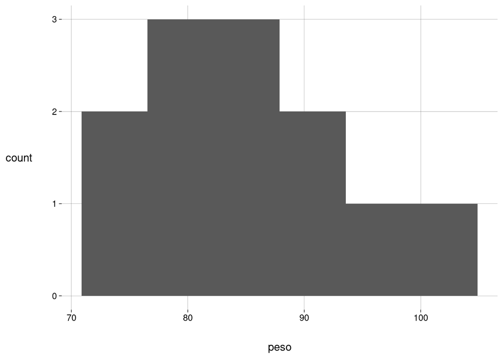

```r
medidas %>%
  ggplot(aes(x = peso)) +
    geom_histogram(bins = 6)
```

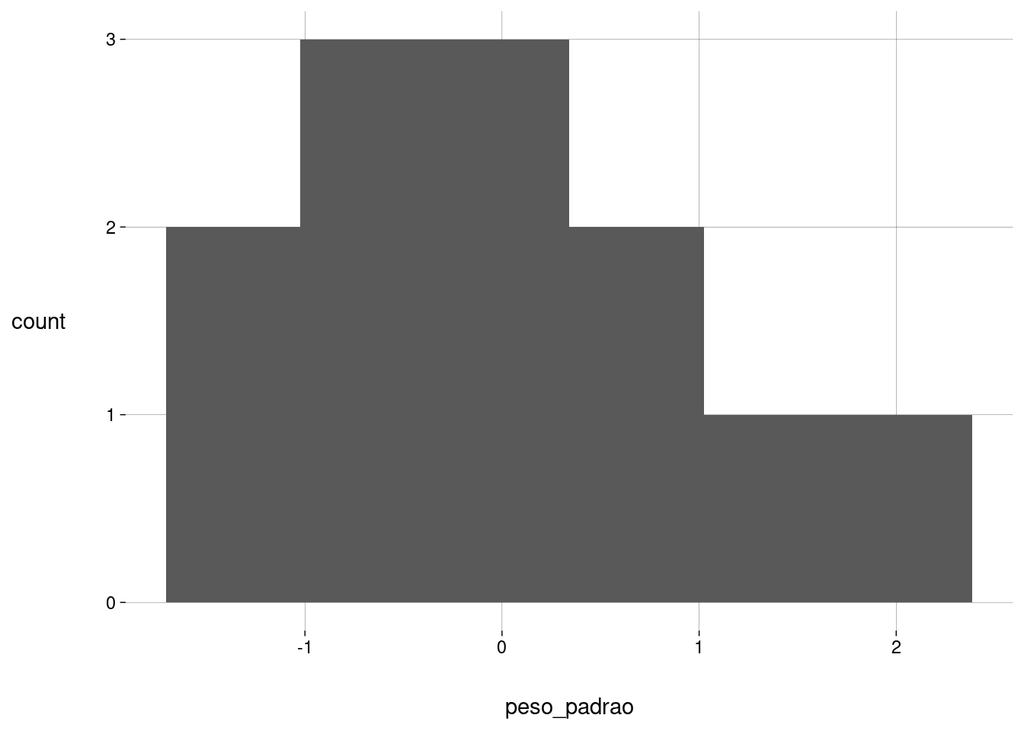

```r
medidas %>%
  ggplot(aes(x = peso_padrao)) +
    geom_histogram(bins = 6)
```

# 8 Teorema de Tchebychev

Em *qualquer* distribuição, a proporção de dados dentro de $\pm k$ desvios padrão ($k > 1$) da média é de, *no mínimo*
$$1 - \frac{1}{k^2}$$

### Exemplo

```r
df <- msleep$sleep_total %>%
  as_tibble()
```

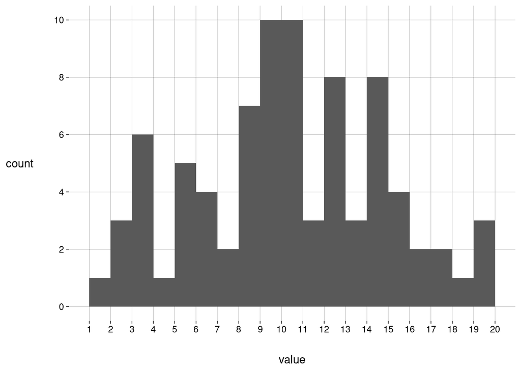

```r
grafico <- df %>%
  ggplot(aes(x = value)) +
    geom_histogram(breaks = 1:20) +
    scale_x_continuous(breaks = 1:20) +
    scale_y_continuous(breaks = seq(0, 10, 2))

grafico
```

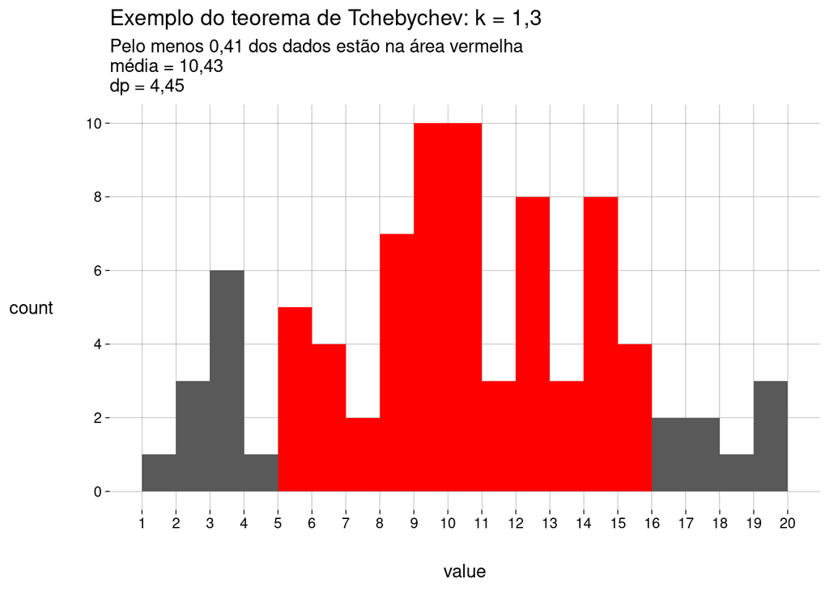

```r
media <- mean(df$value)
dp <- sd(df$value)

k <- 1.3

inicio <- media - k * dp
fim <- media + k * dp

proporcao <- 1 - 1 / k^2

grafico +
  geom_histogram(
    data = df %>%
      filter(value >= inicio & value <= fim),
    fill = 'red',
    breaks = 1:20
  ) +
  labs(
    title = paste('Exemplo do teorema de Tchebychev: k =', k),
    subtitle = paste(
      'Pelo menos', round(proporcao, 2), 'dos dados estão na área vermelha',
      '\nmédia =', round(media, 2),
      '\ndp =', round(dp, 2)
    )
  )
```